# Re-analysis of the microarray data published by Murat, A. et al. (2008) “Stem Cell–Related “Self-Renewal” Signature and High Epidermal Growth Factor Receptor Expression Associated With Resistance to Concomitant Chemoradiotherapy in Glioblastoma”

### Álvaro Abella Bascarán (alvaro.abella01@estudiant.upf.edu)

### Eloi Casals (eloi.casals01@estudiant.upf.edu)

### Samuel Miravet Verde (samuel.miravet01@estudiant.upf.edu)

## Introduction

Glioblastoma multiforme is the most presented and aggressive brain tumor in humans, involving glial cells, with an incidence of 2–3 cases per 100,000 person life-years in Europe and North America ([Fonnet E. Bleeker, *et al* (2012)](http://www.ncbi.nlm.nih.gov/pmc/articles/PMC3337398/)).

Treatment can involve chemotherapy, radiation and surgery. Median survival with standard-of-care radiation and chemotherapy with the alkylating agent temozolomide is 15 months([Johnson, Derek R. *et al* (2011)](http://link.springer.com/article/10.1007%2Fs11060-011-0749-4)) while the median survival without treatment is 4 and a half months. Regretfully glioblastomas are notorious for resistance to therapy, which has been attributed to DNA-repair proficiency, a multitude of deregulated molecular pathways, and, more recently, to the particular biologic behavior of tumor stem-like cells. Here, based on the reference work of [Murat, A. *et al* (2008)](http://www.ncbi.nlm.nih.gov/pubmed/18565887), we aimed to identify the molecular profiles specific for treatment resistance to the current standard of care of concomitant chemoradiotherapy with temozolomide.

To achieve our goal, we take from the reference study a set of gene expression profiles of 80 glioblastomas of patients treated whithin clinical trials of concomitant and adjuvant temozolomide to radiotherapy (n=52) and patients treated with only radioterapy (n=28). In addition, 4 control patients were added to the study.

This document should be processed from R and you need to install the packages [knitr](http://cran.r-project.org/web/packages/knitr/index.html) and [markdown](http://cran.r-project.org/web/packages/markdown/index.html). Once they are installed, you have to type the following instructions that generate a HTML document that you can open with a web browser:

```
library(knitr)     ## required for "knitting" from Rmd to md
library(markdown)  ## required for processing from md to HTML
knit("projectTemplate.Rmd", "projectTemplate.md")  ## process Rmd to md
markdownToHTML("projectTemplate.md", "projectTemplate.html") ## process md to HTML
browseURL("projectTemplate.html") ## open the resulting HTML file from R
```

## Data

The microarray data used during the research of [Murat, A. *et al* (2008)](http://www.ncbi.nlm.nih.gov/pubmed/18565887) can be found at the [Gene Expression Omnibus](http://www.ncbi.nlm.nih.gov/geo/), with the accession number GSE7696. In order to proceed with this analysis, the file [GSE7696_RAW.tar](http://www.ncbi.nlm.nih.gov/geo/download/?acc=GSE7696&format=file) must be uncompressed under the directory ‘data/raw/’ and the file GSE7696_series_matrix.txt.gz must be placed inside ‘data/’.

## Subsampling

We need GEOquery to retrieve the assay data and affy to handle data from Affymetrix 3’-biased Arrays.

```r
library(affy)
library(GEOquery)
```

This is a simple way to cache the full eset (all the assay data) in a simple object, to avoid loading it from the .txt.gz the next time (a costly process).

```r
# Cache the data to avoid having to load it again next time from the .txt
if (file.exists('full_eset.rds')) {
  eset = readRDS('full_eset.rds')
} else {
  eset = getGEO(filename='data/GSE7696_series_matrix.txt.gz')
  saveRDS(eset, 'full_eset.rds')
}
```

```r
# extract sample names
samples = colnames(eset)

# take only treated samples
treated = samples[eset$characteristics_ch1.5 != "treatment: NA"]

# turn sample names into filenames
subsample_filenames = paste(treated, '.cel.gz', sep='')

# read only the necessary the expression data
glioData = ReadAffy(celfile.path = "./data/raw", filenames=subsample_filenames)

nsamples = length(sampleNames(glioData))
sampleNames(glioData) = c(1:nsamples)
```

We also filter the original assay data to keep only the data corresponding to the samples we have choosen. We finally save both objects for posterior use.

```r
subsampled_eset = eset[, treated]

# save the subsampled data for posterior use

if (!file.exists('eset.rds')) {
  saveRDS(subsampled_eset, 'eset.rds')
}
if (!file.exists('glioData.rds')) {
  saveRDS(glioData, 'glioData.rds')
}

eset = subsampled_eset
```

## Quality assessment

```r
library(affyPLM)
```

### Analysis of intensities

We can further assess the quality of the samples analysing the distribution of intensities from each chip. Chips with a distribution which differs significantly from the rest (in median or dispersion) should be taken with caution.

```r
badSamplesRawDist = ""
```

### Probe level modeling

```r
badSamplesPLMResids = c("38", "27", "8")
```

### Normalized Unscaled Standard Errors (NUSE)

```r
badSamplesNUSE = c("18", "29", "31", "65", "74")
```

### Relative Log Expression (RLE)

Relative Log Expression Values are calculated for each of the probesets. In tis case we compare the expression on each array against the median expression value for the probeset across all of the arrays. The RLE summaries can be helpful to detect technical sources of variability that are large compared to biological variation.

```r
badSamplesRLE = c()
```

## Normalization

### MA plots

The MA plot can help us detect intensity dependent biases. In this case we compare (using a log ratio) the intensity of the red and green channels of the microarray (each representing a different condition). As we expect most of the genes to not be differentially expressed, most of the log ratios should be close to zero. Plotting the log ratio against the mean log intensity of both channels, we can detect dependences of the ratios on the fluorescence intensity.

```r
badSamplesMA = c("1", "39", "71")
```

We can finally display a table showing the number of diagnostics failed by each sample:

```r
qaDiag <- data.frame(RawDist = rep(FALSE, ncol(eset)), PLMresids = rep(FALSE, ncol(eset)), NUSE = rep(FALSE, ncol(eset)), RLE = rep(FALSE, ncol(eset)), MA = rep(FALSE, ncol(eset)), Failed = rep(0, ncol(eset)), row.names = sampleNames(glioData))

qaDiag[badSamplesRawDist, "RawDist"] <- TRUE
qaDiag[badSamplesPLMResids, "PLMresids"] <- TRUE
qaDiag[badSamplesNUSE, "NUSE"] <- TRUE
qaDiag[badSamplesRLE, "RLE"] <- TRUE
qaDiag[badSamplesMA, "MA"] <- TRUE

qaDiag$Failed <- rowSums(qaDiag)
qaDiag <- qaDiag[order(qaDiag$Failed, decreasing = TRUE), ]
qaDiag
```

```
##    RawDist PLMresids  NUSE   RLE    MA Failed
## 1    FALSE     FALSE FALSE FALSE  TRUE      1
## 8    FALSE      TRUE FALSE FALSE FALSE      1
## 18   FALSE     FALSE  TRUE FALSE FALSE      1
## 27   FALSE      TRUE FALSE FALSE FALSE      1
## 29   FALSE     FALSE  TRUE FALSE FALSE      1
## 31   FALSE     FALSE  TRUE FALSE FALSE      1
## 38   FALSE      TRUE FALSE FALSE FALSE      1
## 39   FALSE     FALSE FALSE FALSE  TRUE      1
## 65   FALSE     FALSE  TRUE FALSE FALSE      1
## 71   FALSE     FALSE FALSE FALSE  TRUE      1
## 74   FALSE     FALSE  TRUE FALSE FALSE      1
## 2    FALSE     FALSE FALSE FALSE FALSE      0
## 3    FALSE     FALSE FALSE FALSE FALSE      0
## 4    FALSE     FALSE FALSE FALSE FALSE      0
```

[output cut: 67 more lines]

In general we have achieved very good results as none of the samples fail more than 1 tests so we decide to continue the study with all the samples.

## Batch identification

The main goal of this step consists in finding if there exist any possible batch effect in our dataset, that is technical sources of variation that have been added to the samples during handling ([Leek, *et al* (2010)](http://www.nature.com/nrg/journal/v11/n10/full/nrg2825.html#close)). It is important to detect them in order to ensure that the possible future differences between expressions do not come from a non-biological or scientific variables source.

We start the process loading the following libraries.

```r
library(affy)
library(Biobase)
library(GEOquery)
library(affyPLM)
library(corpcor)
```

Between all the different features our dataset have, the only possible batch source is the experiment date of each sample so this will be our batch grouping variable. To consider it, we have to set a scanDate variable in the correct format:

```r
scanDate = protocolData(glioData)$ScanDate
scanDate = gsub(" .*", "", scanDate)
scanDate = as.Date(scanDate, "%m/%d/%y")
```

Once defined that variable, we are already able to group together the samples obtained in the same date:

```r
minscan = min(scanDate)
days = scanDate- minscan

sort(days)
```

```
## Time differences in days
##  [1]   0   0   0   0   0   0   0   0   0   0   0   2   2   2   2   2   2
## [18]   2   2   2   2   2   2   2   2   2   3   3   3   3   3   3   3   3
## [35]   3   3   3   3   3   3   3   7   7   7   7   7   7   7   7   7   7
## [52]   7   7   7   7   7  10  10  10  10  10  10  10  10  10  10  10  28
## [69]  28  28  28  28 192 192 192 192 192 192 192 192
```

We see 7 different batch groups. In order to ease the process of batch identification, we define 4 new groups based on weeks (1: 0, 2, 3 / 2: 7, 10 / 3: 28 / 4: 192). With those different week groups we can discretize the weeks numeric variable into desired intervals to finally obtain our surrogate batch indicator variable. In addition, the length of the variable *weeks* allows us to define a vector of colors that will be used in the posterior plots.

```r
# Assign new groups by weeks:
batch_weeks <- cut(as.numeric(days), c(-1, 6, 20, 50, 200))
batch_weeks <- as.numeric(batch_weeks)
batch_weeks
```

```
##  [1] 1 1 3 2 2 2 1 2 1 2 1 1 1 1 1 1 4 1 4 1 2 1 4 4 4 4 4 1 1 2 2 2 1 1 2
## [36] 1 2 2 1 2 1 1 1 2 1 1 2 1 3 2 1 1 1 1 1 2 2 1 3 2 2 2 1 1 2 1 2 1 2 2
## [71] 1 1 1 2 1 1 3 1 3 4
```

The differential outcome for our dataset is the recurrence as the aim of the study is to define a set of genes expressed differentially between resistant cancer patients and non-resistant. To consider it, we extract the variable from the *eset* and transform it into a character string.

```r
disease_status = eset$characteristics_ch1.1
disease_status = gsub('.*: ', '', disease_status)
disease_status = as.character(disease_status)
```

The division of our outcome respect the batch groups can be resumed with the *table* function:

```r
table(data.frame(Outcome = disease_status, Batch = batch_weeks))
```

```
##                   Batch
## Outcome             1  2  3  4
##   GBM              39 24  5  2
##   recurrent GBM     2  2  0  5
##   re-recurrent GBM  0  0  0  1
```

We see the batch variable across samples is clearly not balanced.

### Hierarchical Clustering

A nice way to see how effectively batch is confounding the outcome of interest consists of doing a hierarchical clustering of the samples indicating the batch to which each of them belongs to. We should start by calculating the distance between every pair of samples using a non-parametric association measure such as [Spearman correlation](http://en.wikipedia.org/wiki/Spearman%27s_rank_correlation_coefficient):

```r
d = as.dist(1 - cor(exprs(eset), method="spearman"))
```

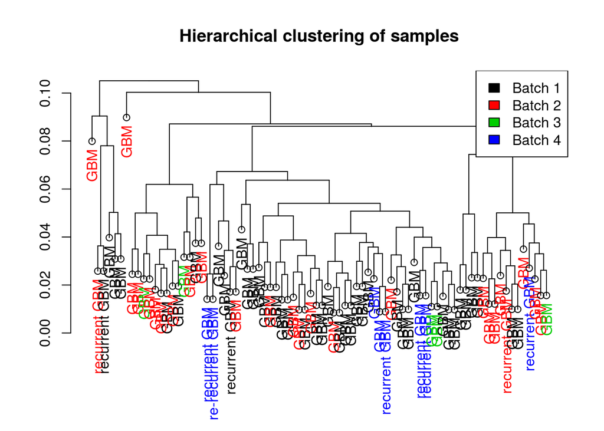

```r
# Hierarchical analysis:

sampleClustering = hclust(d)

# Function to generate the dendrogram:

batch = batch_weeks
sampleDendrogram <- as.dendrogram(sampleClustering, hang = 0.1)
names(batch) <- sampleNames(eset)
names(disease_status) <- sampleNames(eset)
sampleDendrogram <- dendrapply(sampleDendrogram, function(x, batch, labels) {
    ## for every node in the dendrogram if it is a leaf node
    if (is.leaf(x)) {
        attr(x, "nodePar") <- list(lab.col = as.vector(batch[attr(x, "label")]))  ## color by batch
        attr(x, "label") <- as.vector(labels[attr(x, "label")])  ## label by disease_status
    }
    x
}, batch, disease_status)

# And the required command to plot it:

plot(sampleDendrogram, main = "Hierarchical clustering of samples")
legend("topright", paste("Batch", sort(unique(batch))), fill = sort(unique(batch)))
```

In this dendrogram we can see that our samples do not cluster by batch, indicating that apparently in this case we don’t have batch effect. We would like to identify a separation by recurrence, but it is clear that the different recurrences are mixed. We don’t see, so far, a relationship among different recurrence and expression.

### Multidimensional Scaling

Another way to verify whether batch is the main source of variation is [multidimensional scaling](http://en.wikipedia.org/wiki/Multidimensional_scaling) analysis. To perform it, we have to run the function *cmdscale*. The resulting *cmd* object have to be a matrix of dimension (n,2) where n=number of samples.

```r
cmd = cmdscale(as.dist(1 - cor(exprs(eset), method = "spearman")))

dim(cmd)
```

```
## [1] 80  2
```

```r
head(cmd)
```

```
##                    [,1]          [,2]
## GSM187153 -0.0145894207 -0.0310556717
## GSM187154  0.0171579965 -0.0083467111
## GSM187155  0.0002148842 -0.0092702272
## GSM187157 -0.0164267032 -0.0120822501
## GSM187158  0.0080240292 -0.0004527915
## GSM187159 -0.0232265937  0.0071240791
```

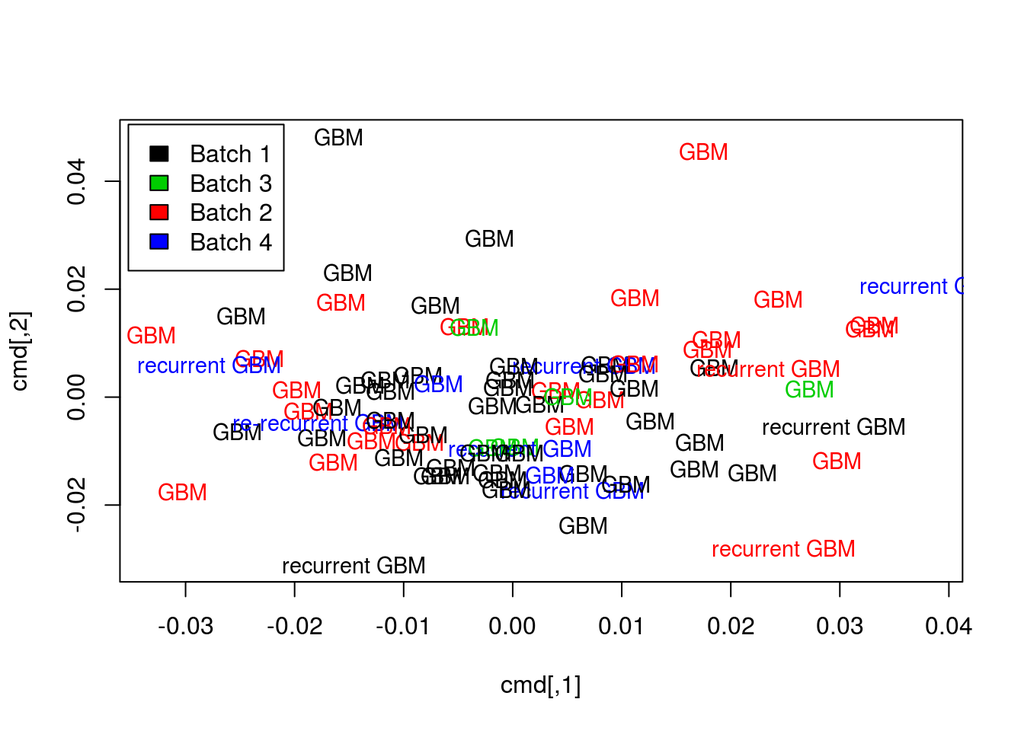

```r
# Ploting the result
plot(cmd, type = "n")
text(cmd, disease_status, col = batch, cex = 0.9)
legend("topleft", paste("Batch", unique(batch)), fill = unique(batch), inset = 0.01)
```

All the recurrence status are mixed well and we cannot detect any color group in the distribution meaning that there is no bacth effect that could confound a possible differential classification of the outcome.

### Quantifying Confounding

The last test we are going to perform is the quantification of confounding between batch and outcome by means of a [Principal Component Analysis](http://en.wikipedia.org/wiki/Principal_component_analysis) test. It works rebuilding the data set in new variables (Principal Components) in terms of linear combinations, such that they capture most of the variance of the data. The purpose of applying PCA in this case is to compare the principal components that account for the largest variability of the data, to known variables such as a batch indicator.

We start the process computing the [single value decomposition](http://en.wikipedia.org/wiki/Singular_value_decomposition) (SVD) of the data:

```r
s = fast.svd(t(scale(t(exprs(eset)), center=TRUE, scale=TRUE)))
```

This value allows us to plot the fraction of variance explained by each principal component as follows:

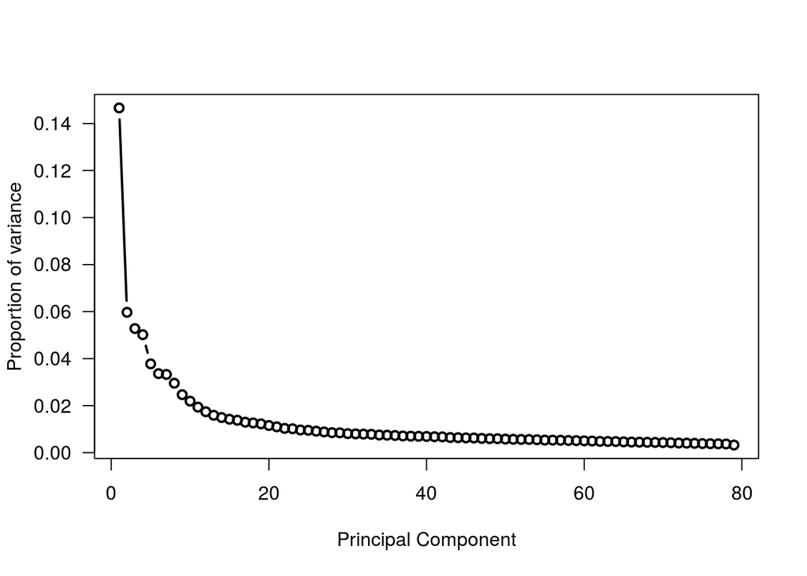

```r
plot(s$d^2/sum(s$d^2), type="b", lwd=2, las=1, xlab="Principal Component", ylab="Proportion of variance")
```

Using the function *cumsum* we can evaluate the amount variance accumulated with each principal component:

```r
head(cumsum(s$d^2/sum(s$d^2)), 12)
```

```
##  [1] 0.1466336 0.2063352 0.2591339 0.3093153 0.3470936 0.3807149 0.4139918
##  [8] 0.4435431 0.4682145 0.4901375 0.5095110 0.5269180
```

In this case we explain more than 50% of variance considering 11 principal components.

Finally, in order to get an estimate the amount of variability driven by batch, we should inspect the correlations between our batch indicator variable and the right-singular vectors in the component *v* of *s*:

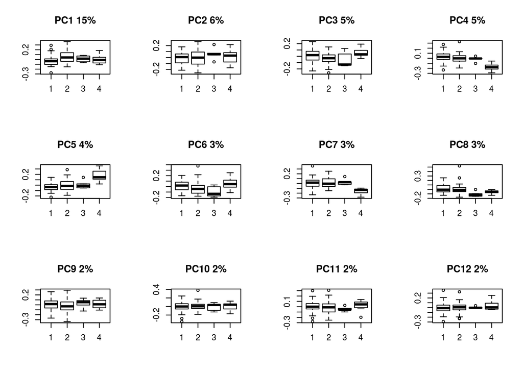

```r
par(mfrow=c(3, 4))
for (i in 1:12) {
  boxplot(split(s$v[, i], batch), main=sprintf("PC%d %.0f%%", i, 100 * s$d[i]^2/sum(s$d^2)))
}
```

We can see the distribution, for each of the batch subgroups, of each of the twelve principal components. We can appreciate that the batch number 2 has a wider distribution across components 1 and 2, while batch number 4 exhibits more variance in components 4 and 5. The results are, however, hard to interpret due to the low (and different) number of samples in each of the subgroups and we should not infer a batch effect from this analysis.

### Surrogate Variable Analysis

With the SVA we try to identify sources of heterogeneity (eg. non-biological variability due to batch effects). With this analysis we should obtain an estimation of the surrogate variables and their values, which we can later use to adjust for undesirable effects.

```r
library(sva)
# We need the outcome variable in binary format, with a threshold of 20 months of survival
st_bin <- ifelse(disease_status != "GBM", 1, 0)

# Define the full and null models
mod = model.matrix(~st_bin, data=pData(eset))
head(mod)
```

```
##           (Intercept) st_bin
## GSM187153           1      1
## GSM187154           1      0
## GSM187155           1      0
## GSM187157           1      0
## GSM187158           1      0
## GSM187159           1      0
```

```r
mod0 <- model.matrix(~1, data = pData(eset))

# surrogate variables calling
sv <- sva(exprs(eset), mod, mod0)
```

```
## Number of significant surrogate variables is:  17
## Iteration (out of 5 ):1  2  3  4  5
```

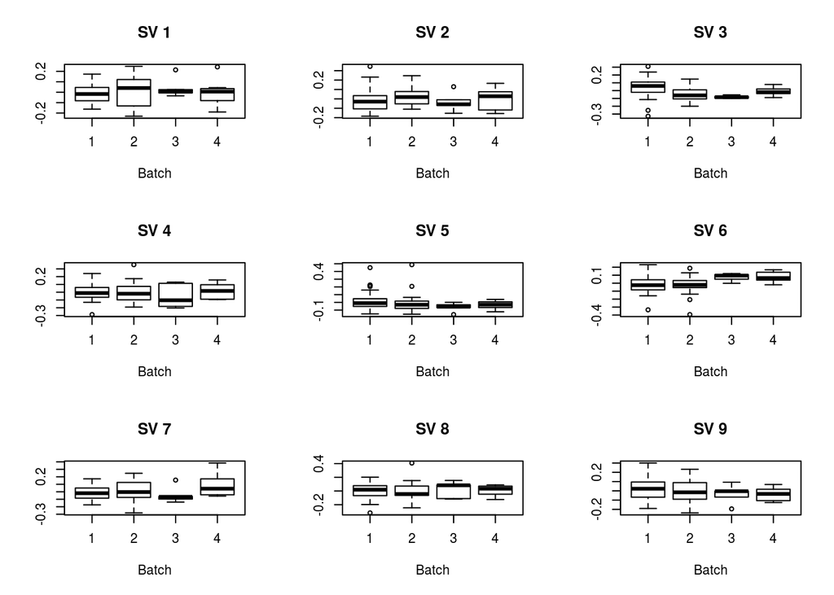

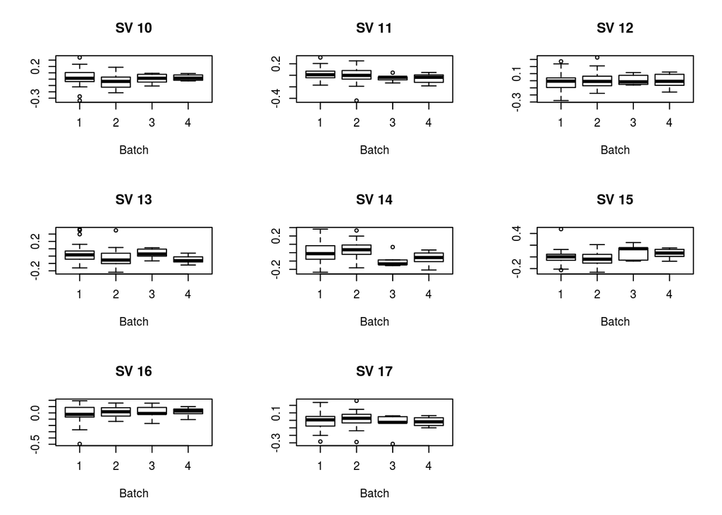

```r
# Plot the correlations
par(mfrow = c(3, 3))
for (i in 1:sv$n.sv) boxplot(sv$sv[, i] ~ batch, main = sprintf("SV %d", i), xlab = "Batch")
```

The boxplots show almost no correlation of the batch indicator variable with every of the estimated surrogate variables.

The *sva* package also provides a function to quickly perform F-tests for detecting genes significantly changing between the full and null models. This enables a quick overview of the impact of adjusting for the estimated heterogeneity:

```r
# Number of genes changing
pValues <- f.pvalue(exprs(eset), mod, mod0)
sum(p.adjust(pValues, method = "BH") < 0.05)
```

```
## [1] 1565
```

```r
dim(eset)
```

```
## Features  Samples
##    54675       80
```

```r
# Changes after adjustment
modSv <- cbind(mod, sv$sv)
mod0Sv <- cbind(mod0, sv$sv)
pValuesSv <- f.pvalue(exprs(eset), modSv, mod0Sv)
sum(p.adjust(pValuesSv, method = "BH") < 0.05)
```

```
## [1] 4445
```

We see more than 4000 genes with a significant change between the full and null model.

After the analysis conducted so far, we can assert that there is no batch effect in our samples. However, we have also seen that the samples corresponding to different recurrence have clustered in a rather heterogeneous way, which might indicate a lack of relationship among gene expression and survival when we take into account all the groups at the same time.

## Differential expression

With the aim to identify changes in gene expression associated to a specific condition, we perform a gene differential expression analysis. The condition in this analysis is the recurrence status in patients.

```r
library(Biobase)
library(genefilter)
library(limma)
library(sva)
library('hgu133plus2.db')
annotation(eset)<-'hgu133plus2.db'
```

First we setup the input data in a format suitable for the analysis.

```r
eset$characteristics_ch1.1 = factor(eset$characteristics_ch1.1) # disease status: re-recurrent GBM
eset$characteristics_ch1.2 = factor(eset$characteristics_ch1.2) # patient id
eset$characteristics_ch1.3 = factor(eset$characteristics_ch1.3) # age: dd.d
eset$characteristics_ch1.4 = factor(eset$characteristics_ch1.4) # gender: MALE/FEMALE
eset$characteristics_ch1.5 = factor(eset$characteristics_ch1.5) # treatment: radiotherapy or TMZ/radiotherapy
eset$characteristics_ch1.6 = factor(eset$characteristics_ch1.6) # survival status: 0 or 1
eset$characteristics_ch1.7 = factor(eset$characteristics_ch1.7) # survival time in months: 25.13
eset$characteristics_ch1.8 = factor(eset$characteristics_ch1.8) # mgmt status: M or U
eset$mgmt = eset$characteristics_ch1.8
eset$treatment = eset$characteristics_ch1.5

#eset$disease_status = ifelse(eset$characteristics_ch1.1 == "recurrent GBM", 1, 0)
eset$disease_status = grepl("recurrent",eset$characteristics_ch1.1)

# Transforming some variables to dichotomic
survival_threshold = 20
eset$survival_time_dichotomic = as.double(gsub('.*: ', '', eset$characteristics_ch1.7)) > survival_threshold
eset$survival_time_dichotomic = factor(eset$survival_time_dichotomic)

age_threshold = 50
eset$aged = as.double(gsub('.*: ', '', eset$characteristics_ch1.3)) > age_threshold
eset$aged = factor(eset$aged)
```

### Fold-change

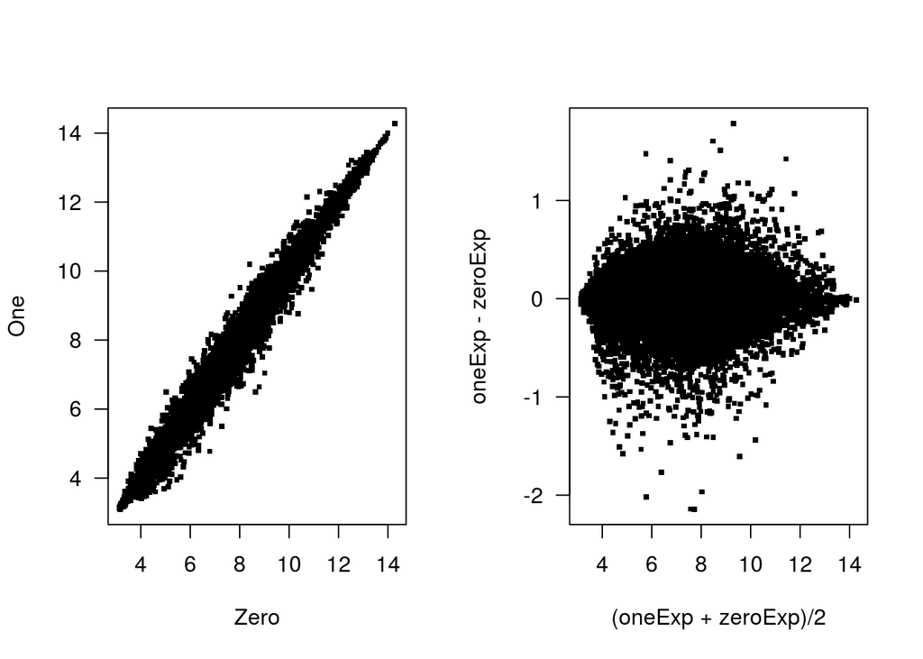

```r
zeroExp <- rowMeans(exprs(eset[, eset$disease_status]))
oneExp <- rowMeans(exprs(eset[, eset$disease_status != TRUE]))
par(mfrow = c(1, 2))
plot(zeroExp, oneExp, xlab = "Zero", ylab = "One", pch = ".", cex = 4, las = 1)
plot((oneExp + zeroExp)/2, oneExp - zeroExp, pch = ".", cex = 4, las = 1)
```

We can see that, in general, all the genes cluster together. We have certain points that deviate from the bulk, but not enough to imply an obvious differential expression. However, we can proceed with further analysis to verify this.

### Removing less variable genes

A first solution to avoid multiple testing problems consists in removing genes that are uninteresting biologically-wise.

We could remove genes that show little variation following the process that eliminates the 30% of genes with less variability in the following way:

```r
# IQRs <- esApply(eset, 1, IQR)
# plot.ecdf(IQRs, xlab = "IQR", main = "Empirical CDF of IQR values")
# abline(v = quantile(IQRs, prob = 0.3), col = "red", lwd = 2)
#
# maskHighVariability <- IQRs > quantile(IQRs, prob = 0.3)
# length(maskHighVariability)
#
# sum(maskHighVariability)
#
# eset_filtered <- eset[maskHighVariability, ]
#
# dim(eset_filtered)
```

The best way to reduce the number of analysed probe sets is by *nsFilter*. This utility function filters out features exhibiting little variation, or a consistently low signal, across samples, as well as features with insufficient annotation.

```r
filtered <- nsFilter(eset, require.entrez=TRUE,
         require.GOBP=FALSE, require.GOCC=FALSE,
         require.GOMF=FALSE, require.CytoBand=FALSE,
         remove.dupEntrez=TRUE, var.func=IQR,
         var.cutoff=0.5, var.filter=TRUE,
         filterByQuantile=TRUE, feature.exclude="^AFFX")
eset_filtered <- filtered$eset
```

With this, we have generated a new *eset* dataset containing less probe sets: 10195, compared with the initial set of 54675.

### Moderated t-test using limma

To prevent problems associated to limited replication, we use the empirical Bayes method from the Bioconductor limma package to calculate a moderated t-test that takes into account the typical standard deviation of the genes.

We project our data to a linear model and calculate the moderated t-statistics.

```r
design <- model.matrix(~disease_status, data = eset_filtered)
fit <- lmFit(eset_filtered, design)
fit <- eBayes(fit)
res <- decideTests(fit, p.value = 0.1)
summary(res)
```

```
##    (Intercept) disease_statusTRUE
## -1           0                 34
## 0            0              10125
## 1        10195                 36
```

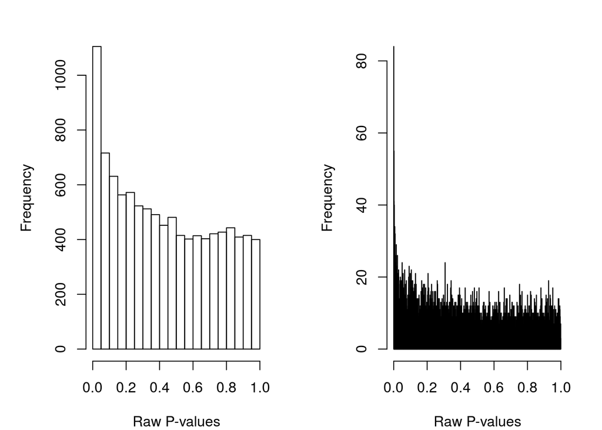

```r
tt <- topTable(fit, coef = 2, n = Inf)
par(mfrow = c(1, 2), mar = c(4, 5, 2, 2))
hist(tt$P.Value, xlab = "Raw P-values", main = "")
hist(tt$P.Value, xlab = "Raw P-values", breaks = 1000, main = "")
```

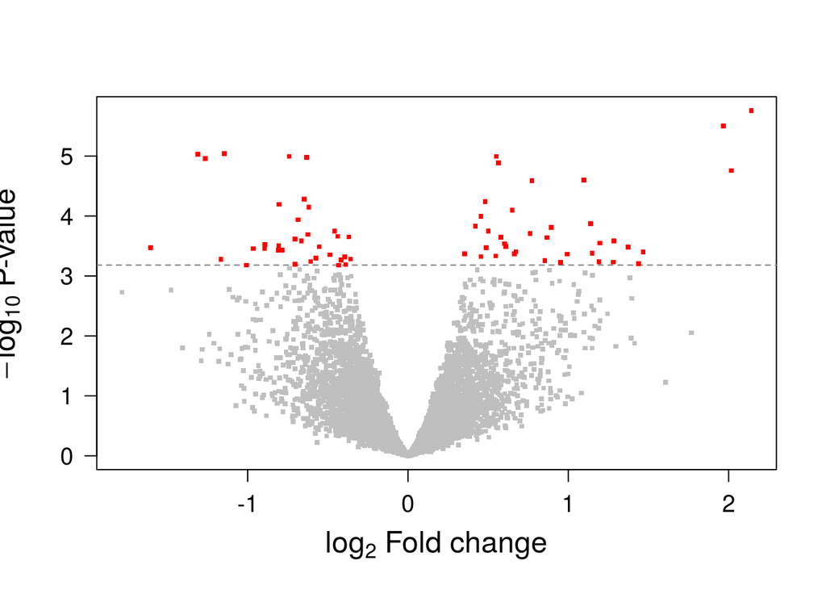

```r
par(mfrow=c(1,1))
plot(tt$logFC, -log10(tt$P.Value), pch=".", cex=4, col=grey(0.75), cex.axis=1.2, las=1, cex.lab=1.5, xlab=expression(paste(log[2], " Fold change")), ylab=expression(paste(-log[10], " P-value")))
if (sum(tt$adj.P.Val < 0.1) > 0) {
  abline(h=-log10(max(tt[tt$adj.P.Val < 0.1, "P.Value"])), col=grey(0.5), lty=2)
}
points(tt[tt$adj.P.Val < 0.1, "logFC"], -log10(tt[tt$adj.P.Val < 0.1, "P.Value"]), pch=".", cex=4, col="red")
```

We see in red in the volcano plot those genes apparently differentially expressed.

### Adjusting for covariates

We can adjust for the contribution of covariates. As proposed in the paper, we adjust for MGMT methylation status and for age>50.

```r
eset_filtered$mgmtM = eset_filtered$mgmt == "mgmt status: M"

# Surrogate Variables
# adjusted for age (> 50 years) and MGMT methylation status
mod <- model.matrix(~disease_status + mgmtM + aged, data = eset_filtered)
mod0 <- model.matrix(~ mgmtM + aged, data = eset_filtered)

svaobj <- sva(exprs(eset_filtered), mod, mod0)
```

```
## Number of significant surrogate variables is:  15
## Iteration (out of 5 ):1  2  3  4  5
```

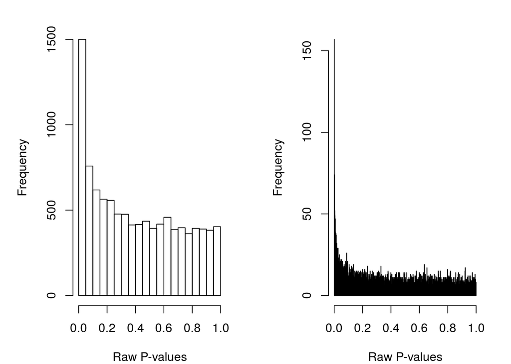

```r
modSVs <- cbind(mod, svaobj$sv)

fit <- lmFit(eset_filtered, modSVs)
fit <- eBayes(fit)
ttadj <- topTable(fit, coef = 2, n = Inf)

par(mfrow = c(1, 2), mar = c(4, 5, 2, 2))
hist(ttadj$P.Value, xlab = "Raw P-values", main = "")
hist(ttadj$P.Value, xlab = "Raw P-values", breaks = 1000, main = "")
```

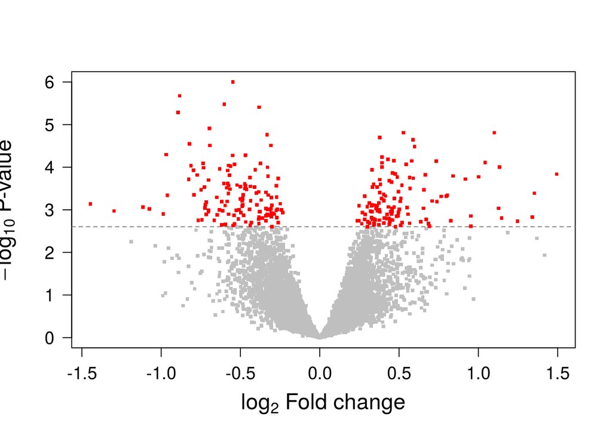

```r
plot(ttadj$logFC, -log10(ttadj$P.Value), pch=".", cex=4, col=grey(0.75), cex.axis=1.2, las=1, cex.lab=1.5, xlab=expression(paste(log[2], " Fold change")), ylab=expression(paste(-log[10], " P-value")))
if (sum(ttadj$adj.P.Val < 0.1) > 0) {
  abline(h=-log10(max(ttadj[ttadj$adj.P.Val < 0.1, "P.Value"])), col=grey(0.5), lty=2)
}
points(ttadj[ttadj$adj.P.Val < 0.1, "logFC"], -log10(ttadj[ttadj$adj.P.Val < 0.1, "P.Value"]), pch=".", cex=4, col="red")
```

We see that the number of genes differentially expressed have been increased after the correction.